# WiDS Incubator Project: Outbrain Click Prediction

Alex Cho, Kenneth Lipke, Parisa Gandomkar

## Overview

[figure not shown]

This project involved improving Outbrain’s recommendation algorithm by predicting which pieces of content its global base of users are likely to click on. Given a set of ads displayed on a web page, we were tasked to accurately rank the advertisements based on their likelihood of receiving a click.

## Exploratory Data Analysis

### Entity Relationship Diagram

[figure not shown]

## Looking at the Data

```python
import pandas as pd
import numpy as np
import matplotlib.mlab as mlab
import matplotlib.pyplot as plt
#Load existing ads_table
#ads_table = pd.read_csv('ads_table.csv')
#train data
#click_train = pd.read_csv('new_train.csv')
```

## Page views

File size: 90+ GB

Over 2 billion observations

## Events

File size: 1.2 GB

Over 23 million rows

## Ads

```python
#Replacing NaNs with 0's
ads_table = ads_table.drop(columns=['Count_Displayed'])
ads_table['Count_Clicks'].fillna(0);
ads_table['Count_ClickDisplayed'].fillna(0);
ads_table['Proportion_Clicks'].fillna(0);
ads_table.head(10)
```

|  | ad_id | document_id | campaign_id | advertiser_id | Count_Clicks | Count_ClickDisplayed | Proportion_Clicks |
| --- | --- | --- | --- | --- | --- | --- | --- |
| 0 | 1 | 6614 | 1 | 7 | 0.0 | 2.0 | 0.000000 |
| 1 | 2 | 471467 | 2 | 7 | 1.0 | 22.0 | 0.045455 |
| 2 | 3 | 7692 | 3 | 7 | 11.0 | 161.0 | 0.068323 |
| 3 | 4 | 471471 | 2 | 7 | 4.0 | 32.0 | 0.125000 |
| 4 | 5 | 471472 | 2 | 7 | 0.0 | 1.0 | 0.000000 |
| 5 | 6 | 12736 | 1 | 7 | 0.0 | 1.0 | 0.000000 |
| 6 | 7 | 12808 | 1 | 7 | 985.0 | 3406.0 | 0.289196 |
| 7 | 8 | 471477 | 2 | 7 | 4.0 | 28.0 | 0.142857 |
| 8 | 9 | 13379 | 1 | 7 | 0.0 | 3.0 | 0.000000 |
| 9 | 10 | 13885 | 1 | 7 | 9.0 | 81.0 | 0.111111 |

#### Count_Clicks

Number of clicks each ad received given there was a click in its display group

#### Count_ClickDisplayed

Number of times each ad was displayed in a display group

#### Proportion_Clicks

Proportion of Count_Clicks / Count_ClickDisplayed

### Ads Table- Count Clicks Column

#### Summary statistics of the number of times each ad was clicked, displayed, and the proportion of the two

[figure not shown]

#### Distribution of the number of times each ad was clicked, displayed, and the proportion of the two

[figure not shown]

#### Using log scale for Proportion of Clicks

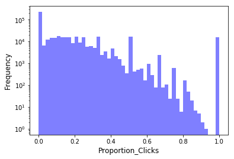

```python
x = ads_table_drop['Proportion_Clicks']
num_bins = 50
fig, ax = plt.subplots()
n, bins, patches = plt.hist(x, num_bins, facecolor='blue', alpha=0.5)
plt.xlabel('Proportion_Clicks', fontsize=12)
plt.ylabel('Frequency', fontsize=12)
ax.set_yscale('log')
plt.show()
```

#### Correlation between potential ad features and clicks

```python
click_train_features = click_train[['Count_Clicks', 'Count_ClickDisplayed', 'Proportion_Clicks', 'clicked']]
click_train_features.corr()
```

[figure not shown]

## Documents

```python
import pandas as pd
import matplotlib.pyplot as plt
```

```python
dc = pd.read_csv("documents_categories.csv")
de = pd.read_csv("documents_entities.csv")
dm = pd.read_csv("documents_meta.csv")
dt = pd.read_csv("documents_topics.csv")
```

The documents tables provide information about what is contained in the content of the documents on which the ads appear. For example, we have information on the website itself, e.g., are we looking at ads that appeared on CNN or a blog; what are the documents about, e.g., is it an article, is it an online marketplace; as well as metadata for the document, like the time it was published.

Unfortunately, these are all coded:

```python
dc.category_id.head()
```

```
0    1611
1    1610
2    1807
3    1608
4    1807
Name: category_id, dtype: int64
```

In our models, we focused on a few key pieces of information:

- document category
- publisher
- document topic We ignored things like entity id, because after looking at the documentation for the data, this could be referring to anything from a person mentioned in an article, an organization, or even a location, so we figured this was more trouble than it would be worth. We also ignored published time.

First, a few high-level statistics:

```python
print("Number unique documents: %s" % dc.document_id.nunique() )
```

```
Number unique documents: 2828649
```

Lets take a look at the document categories:

```python
print("Number of categories: %s" % dc.category_id.nunique() )
print("Number of topics: %s" % dt.topic_id.nunique() )
print("Number of publishers: %s" % dm.publisher_id.nunique() )
```

```
Number of categories: 97
Number of topics: 300
Number of publishers: 1259
```

Lets get an idea of how prevelent some of these were

```python
dc.category_id.value_counts().head(20)
```

```
1403    572107
1702    408499
1902    292878
1513    276203
1808    241966
1100    212249
1907    181345
2004    159334
1408    155883
1708    142908
1707    136830
2100    125219
1407    124783
1706    105170
1205    103539
1903     95015
1703     93883
1510     83877
1603     77881
1602     74315
Name: category_id, dtype: int64
```

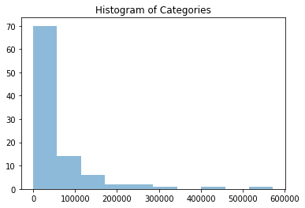

```python
plt.hist(dc.category_id.value_counts(), alpha=.5 )
plt.title("Histogram of Categories")
plt.show()
```

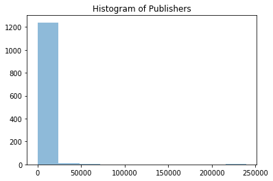

```python
plt.hist(dm.publisher_id.value_counts(), alpha=.5)
plt.title("Histogram of Publishers")
plt.show()
```

## Models

Scores

[figure not shown]

AUC Scores

[figure not shown]

## Next steps

- Try regularized regression methods (ridge regression, lasso, elastic net)
- Try utilizing page_views with a distributed computing environment with Spark
- Explore different features like geo_location and timestamp
- Utilize external data like weather, socioeconomic status of users based on their geo_location

## Takeaways

- Learned how to work with (or avoid working with) large datasets
- Learned how Spark could be utilized
- Interact with Kaggle, api
- Met cool data scientists at Booz Allen

# Appendix

#### Summary Statistics

```python
ads_table['Proportion_Clicks'].describe()
```

```
count    478950.000000
mean          0.143224
std           0.217684
min           0.000000
25%           0.000000
50%           0.051724
75%           0.205882
max           1.000000
Name: Proportion_Clicks, dtype: float64
```

#### Histogram

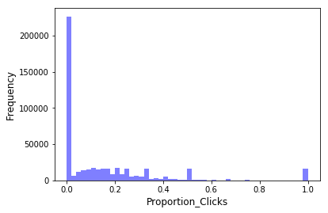

```python
x = ads_table['Proportion_Clicks']
num_bins = 50
n, bins, patches = plt.hist(x, num_bins, facecolor='blue', alpha=0.5)
plt.xlabel('Proportion_Clicks', fontsize=12)
plt.ylabel('Frequency', fontsize=12)
plt.show()
```

#### Scatterplot

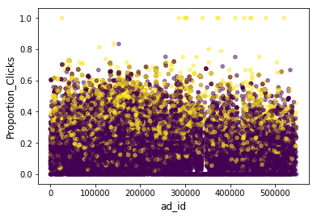

```python
import numpy as np
import matplotlib.pyplot as plt
N = 100000
new_train100000 = click_train.sample(100000);
colors = np.random.rand(N)
area = (30 * np.random.rand(N))**2  # 0 to 15 point radii

plt.scatter(new_train100000['ad_id'], new_train100000['Proportion_Clicks'], s=20, c=new_train100000['clicked'], alpha=0.5)
plt.xlabel('ad_id', fontsize=12)
plt.ylabel('Proportion_Clicks', fontsize=12)
plt.show()
```

#### Bar Graph

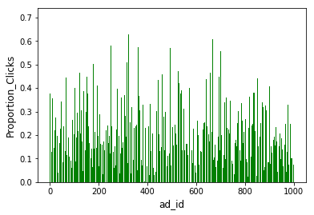

```python
new_train1000 = click_train.sample(1000);
x = new_train1000['ad_id']
y = new_train1000['Proportion_Clicks']
ind = [i for i, _ in enumerate(x)]
plt.bar(ind, y, color='green')
plt.xlabel('ad_id', fontsize=12)
plt.ylabel('Proportion_Clicks', fontsize=12)
plt.show()
```

#### Correlation Heatmap

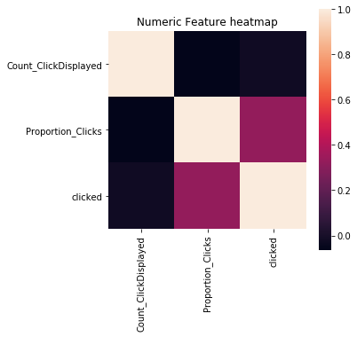

```python
import seaborn as sns
fig,ax = plt.subplots(figsize=(5,5))
correlation = click_train_features.select_dtypes(include=['float64','int64']).iloc[:,1:].corr()
sns.heatmap(correlation,ax=ax,vmax=1,square=True)
plt.title('Numeric Feature heatmap')
plt.savefig('heatmap-count')
```

```python
##Computing ROC AUC Score for different models
import numpy as np
from sklearn.metrics import roc_auc_score
y_true = y_test_AUC

#Log model
roc_auc_score(y_true, y_scores_log)
```

[output not shown]

```python
#Creating a table that looks reasonably nice
import pandas as pd
import numpy as np
d = {'Count Clicks': [0.5933], 'Log Model': [0.7259], 'Log(Log Model)': [0.7259], 'Decision Tree': [0.7259], 'SGD CC': [0.7259]}
df = pd.DataFrame(data=d, index=['AUC Score'])
df
```

|  | Count Clicks | Log Model | Log(Log Model) | Decision Tree | SGD CC |
| --- | --- | --- | --- | --- | --- |
| AUC Score | 0.5933 | 0.7259 | 0.7259 | 0.7259 | 0.7259 |

```python
#Correlation Matrix

click_train_features = click_train[['Count_Clicks', 'Count_ClickDisplayed', 'Proportion_Clicks', 'clicked']]
click_train_features.corr()
```

[output not shown]